# Exam 1

Sydney Ball

2024-02-23

#### Import Library

```r
library(tidyverse)
```

#### Question 1:

Produce and save a DATA TABLE that shows output for Ohio (OH) only. Use the piping method and the appropriate dplyr functions. Then display the first 5 rows.

```r
midwest_q1 <- midwest%>%
  filter(state == "OH")%>%
  print(n=5)
```

```
## # A tibble: 88 × 28
##     PID county   state  area poptotal popdensity popwhite popblack popamerindian
##   <int> <chr>    <chr> <dbl>    <int>      <dbl>    <int>    <int>         <int>
## 1  2009 ADAMS    OH    0.035    25371       725.    25212       47            67
## 2  2010 ALLEN    OH    0.024   109755      4573.    96177    12313           202
## 3  2011 ASHLAND  OH    0.025    47507      1900.    46686      460            49
## 4  2012 ASHTABU… OH    0.041    99821      2435.    95465     3138           196
## 5  2013 ATHENS   OH    0.03     59549      1985.    56163     1678           167
## # ℹ 83 more rows
## # ℹ 19 more variables: popasian <int>, popother <int>, percwhite <dbl>,
## #   percblack <dbl>, percamerindan <dbl>, percasian <dbl>, percother <dbl>,
## #   popadults <int>, perchsd <dbl>, percollege <dbl>, percprof <dbl>,
## #   poppovertyknown <int>, percpovertyknown <dbl>, percbelowpoverty <dbl>,
## #   percchildbelowpovert <dbl>, percadultpoverty <dbl>,
## #   percelderlypoverty <dbl>, inmetro <int>, category <chr>
```

```r
write.csv(midwest_q1, "filtered_midwest_data.csv", row.names = FALSE)
```

#### Question 2:

Produce and save a DATA TABLE that shows the white populations that are greater than 50,000 but less than 90,000 for the state of Indiana (IN). Display first 10 rows. Do not hard code the answer.

```r
midwest_q2 <- midwest%>%
  filter(popwhite >= 50000) %>%
  filter(popwhite <= 90000) %>%
  filter(state == "IN") %>%
  print(n=10)
```

```
## # A tibble: 10 × 28
##      PID county  state  area poptotal popdensity popwhite popblack popamerindian
##    <int> <chr>   <chr> <dbl>    <int>      <dbl>    <int>    <int>         <int>
##  1   665 BARTHO… IN    0.022    63657      2894.    61774     1005            97
##  2   672 CLARK   IN    0.022    87777      3990.    82289     4703           192
##  3   684 FLOYD   IN    0.009    64404      7156     61415     2642            92
##  4   689 GRANT   IN    0.024    74169      3090.    67817     5047           298
##  5   694 HENDRI… IN    0.024    75717      3155.    74519      685           157
##  6   696 HOWARD  IN    0.016    80827      5052.    75420     4398           226
##  7   703 JOHNSON IN    0.018    88109      4895.    86455      845           139
##  8   705 KOSCIU… IN    0.032    65294      2040.    64058      309           118
##  9   717 MORGAN  IN    0.024    55920      2330     55635        9           137
## 10   751 WAYNE   IN    0.024    71951      2998.    67532     3795           153
## # ℹ 19 more variables: popasian <int>, popother <int>, percwhite <dbl>,
## #   percblack <dbl>, percamerindan <dbl>, percasian <dbl>, percother <dbl>,
## #   popadults <int>, perchsd <dbl>, percollege <dbl>, percprof <dbl>,
## #   poppovertyknown <int>, percpovertyknown <dbl>, percbelowpoverty <dbl>,
## #   percchildbelowpovert <dbl>, percadultpoverty <dbl>,
## #   percelderlypoverty <dbl>, inmetro <int>, category <chr>
```

```r
write.csv(midwest_q2, "filtered_midwest_data.csv", row.names = FALSE)
```

#### Question 3:

Produce and save a DATA FRAME (20 observations) that shows only the variables state, county, poptotal, popamerindian, and percamerindian for the state of Indiana. Also, your data table should show popamerindian in descending order. Which county in Indiana has the highest number of Native Americans?

It seems like the county with the highest number of Native Americans is Marion county in Indiana.

```r
midwest_q3 <- midwest %>%
  select(state, county, poptotal, popamerindian, percamerindan) %>%
  filter(state == "IN") %>%
  arrange(desc(popamerindian)) %>%
  print(n=20)
```

```
## # A tibble: 92 × 5
##    state county      poptotal popamerindian percamerindan
##    <chr> <chr>          <int>         <int>         <dbl>
##  1 IN    MARION        797159          1698         0.213
##  2 IN    ALLEN         300836           892         0.297
##  3 IN    LAKE          475594           865         0.182
##  4 IN    ST JOSEPH     247052           846         0.342
##  5 IN    MIAMI          36897           571         1.55
##  6 IN    ELKHART       156198           453         0.290
##  7 IN    TIPPECANOE    130598           320         0.245
##  8 IN    MADISON       130669           299         0.229
##  9 IN    GRANT          74169           298         0.402
## 10 IN    VIGO          106107           297         0.280
## 11 IN    VANDERBURGH   165058           284         0.172
## 12 IN    DELAWARE      119659           274         0.229
## 13 IN    LA PORTE      107066           259         0.242
## 14 IN    WABASH         35069           259         0.739
## 15 IN    PORTER        128932           243         0.188
## 16 IN    HOWARD         80827           226         0.280
## 17 IN    MONROE        108978           216         0.198
## 18 IN    CLARK          87777           192         0.219
## 19 IN    HAMILTON      108936           163         0.150
## 20 IN    HENDRICKS      75717           157         0.207
## # ℹ 72 more rows
```

#### Question 4:

Create a DATA TABLE for only the state of Michigan (MI) showing those counties that have a known poverty population that is greater than 10,000 and a percentage of professionals that is greater than 10 percent. This data frame should only contain the variables that you need for the data frame. (Your output should only have four variables and six observations.)

```r
midwest_q4 <- midwest %>%
  select(state, county, poppovertyknown, percprof) %>%
  filter(state == "MI") %>%
  filter(poppovertyknown > 10000) %>%
  filter(percprof > 10)

midwest_q4
```

```
## # A tibble: 6 × 4
##   state county    poppovertyknown percprof
##   <chr> <chr>               <int>    <dbl>
## 1 MI    INGHAM             261491     12.9
## 2 MI    ISABELLA            48498     10.0
## 3 MI    KALAMAZOO          212670     10.9
## 4 MI    MIDLAND             74135     11.2
## 5 MI    OAKLAND           1070844     11.2
## 6 MI    WASHTENAW          261261     20.8
```

#### Question 5:

Write R code that will show the mean of the poverty population for the counties of each state.

```r
midwest %>%
  select(state, county, poppovertyknown) %>%
  group_by(state) %>%
  summarize("Mean Poverty" = mean(poppovertyknown , na.rm = TRUE))
```

```
## # A tibble: 5 × 2
##   state `Mean Poverty`
##   <chr>          <dbl>
## 1 IL           109253.
## 2 IN            58396.
## 3 MI           109362.
## 4 OH           120163.
## 5 WI            66029.
```

#### Question 6:

Produce a scatter plot with orange dots that shows the relationship between the variables poppovertyknown and poptotal (Let poptotal = x and poppovertyknown = y). Include a centered “blue” title, x and y labels.

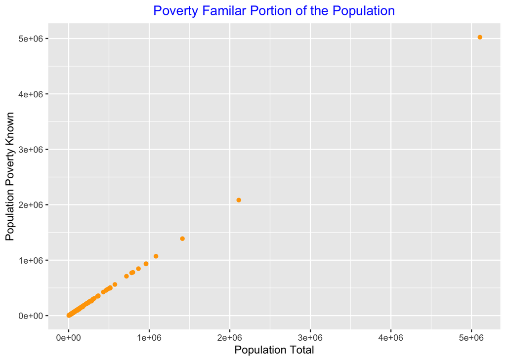

```r
ggplot(data = midwest) +
  geom_point(mapping = aes(x=poptotal, y=poppovertyknown), color = "orange") +
  xlab("Population Total") +
  ylab("Population Poverty Known") +
  ggtitle("Poverty Familar Portion of the Population") +
  theme(plot.title = element_text(hjust = 0.5, color ="blue"))
```

#### Question 7:

Write R code that will produce the following side by side boxplots. Then change the boxes to purple, and the outliers to red. Include personalized labels and a title.

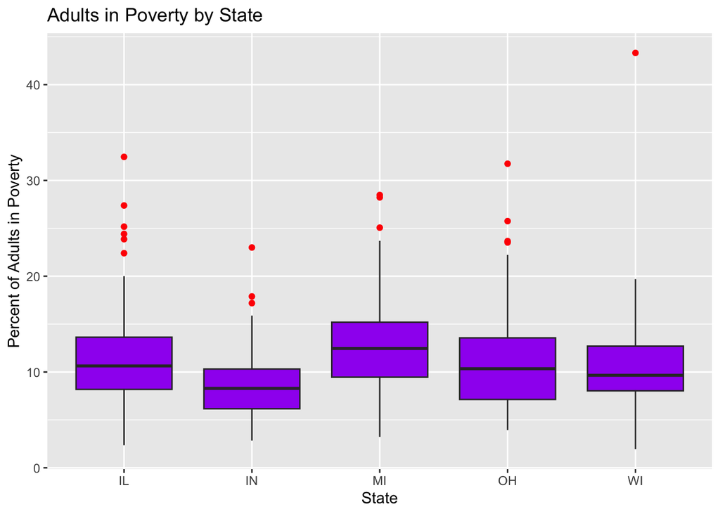

```r
ggplot(data = midwest)  +
  geom_boxplot(mapping = aes(x = state, y = percadultpoverty),
               fill = "purple", outlier.color = "red") +
  xlab("State") +
  ylab("Percent of Adults in Poverty") +
  ggtitle("Adults in Poverty by State")
```

#### Question 8:

Produce a facet plot that shows scatter plots (yellow data points) with respect to the levels for the variable state. Also add code that will generate regression lines through your scatter plots that feature x = percollege and y = percprof. Title your facet plot “College/Professional Work Scatter Plots”.

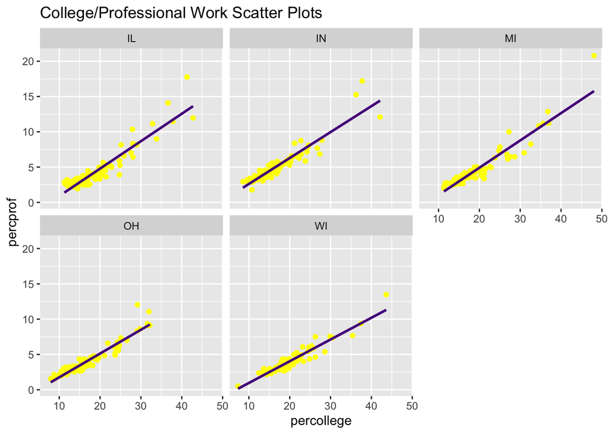

```r
ggplot(data = midwest, aes(x = percollege, y = percprof)) +
  geom_point(color = "yellow") +
  geom_smooth(method = "lm", se = FALSE, color = "purple4") +
  facet_wrap(~state) +
  labs(title = "College/Professional Work Scatter Plots")
```

#### Question 9:

Create a bar graph that shows the different COUNTS for each state in the data set. Your bars should have different colors.

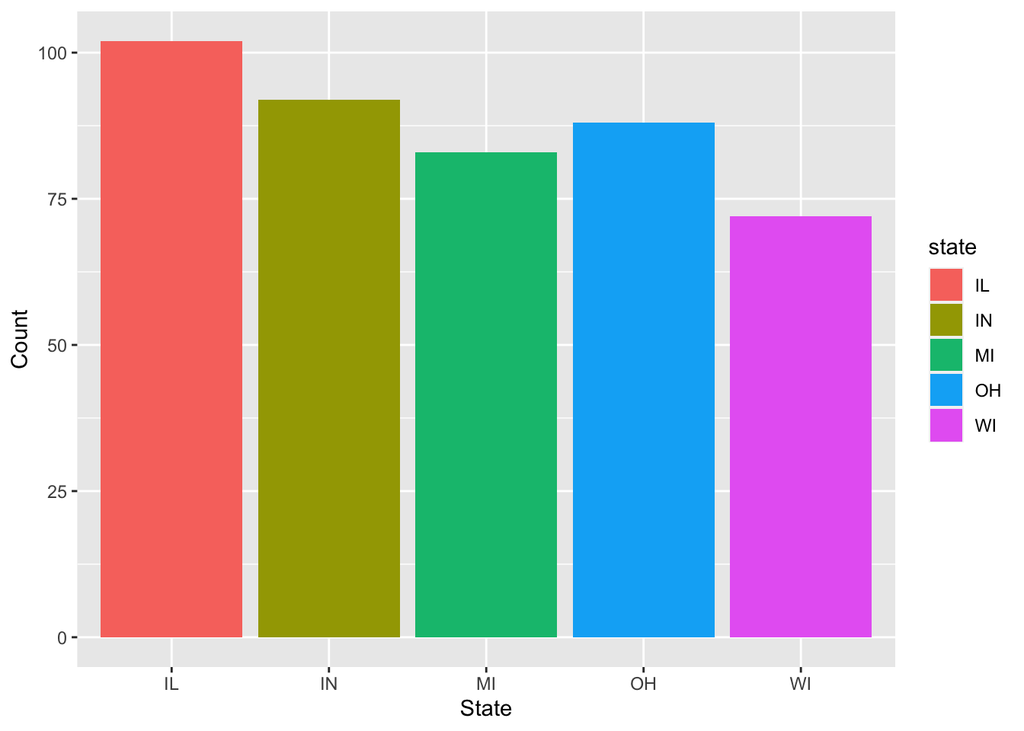

```r
ggplot(data = midwest, aes(x = state, fill = state)) +
  geom_bar() +
  xlab("State") +
  ylab("Count")
```

Which state has the highest count (do not hard code)? It seems Illinois has the highest ‘count.’

```r
max_count_state <- names(which.max(table(midwest$state)))
max_count_state
```

```
## [1] "IL"
```

#### Question 10:

```r
cylindercalc <- function(radius, height) {
  volume = pi * radius^2 * height
  surface_a = 2 * (pi * radius * height + pi * radius^2)
  return(list(volume = volume, surface_a = surface_a))
}

result <- cylindercalc(radius = 5, height = 10)
print(result)
```

```
## $volume
## [1] 785.3982
##
## $surface_a
## [1] 471.2389
```

```r
result <- cylindercalc(radius = 5, height = 10)

cat("For a cylinder with radius 5 and height 10, the volume is", result$volume, "cubic units and the surface area is",result$surface_a, "square units.")
```

```
## For a cylinder with radius 5 and height 10, the volume is 785.3982 cubic units and the surface area is 471.2389 square units.
```